# Discussion 11

## Batter up

We’ll be looking at data from all 30 Major League Baseball teams and examining the linear relationship between runs scored in a season and a number of other player statistics. Our aim will be to summarize these relationships both graphically and numerically in order to find which variable, if any, helps us best predict a team’s runs scored in a season.

## The data

Let’s load up the data for the 2011 season.

```r
load("/Users/cwong79/Dropbox/Public/CUNY/DATA 605/more/mlb11.RData")
```

In addition to runs scored, there are seven traditionally used variables in the data set: at-bats, hits, home runs, batting average, strikeouts, stolen bases, and wins. There are also three newer variables: on-base percentage, slugging percentage, and on-base plus slugging.

If the relationship looks linear, we can quantify the strength of the relationship with the correlation coefficient. Here I am comparing runs versus at bats.

```r
cor(mlb11$runs, mlb11$at_bats)
```

```
## [1] 0.610627
```

Here is another comparison of runs versus hits.

```r
cor(mlb11$runs, mlb11$hits)
```

```
## [1] 0.8012108
```

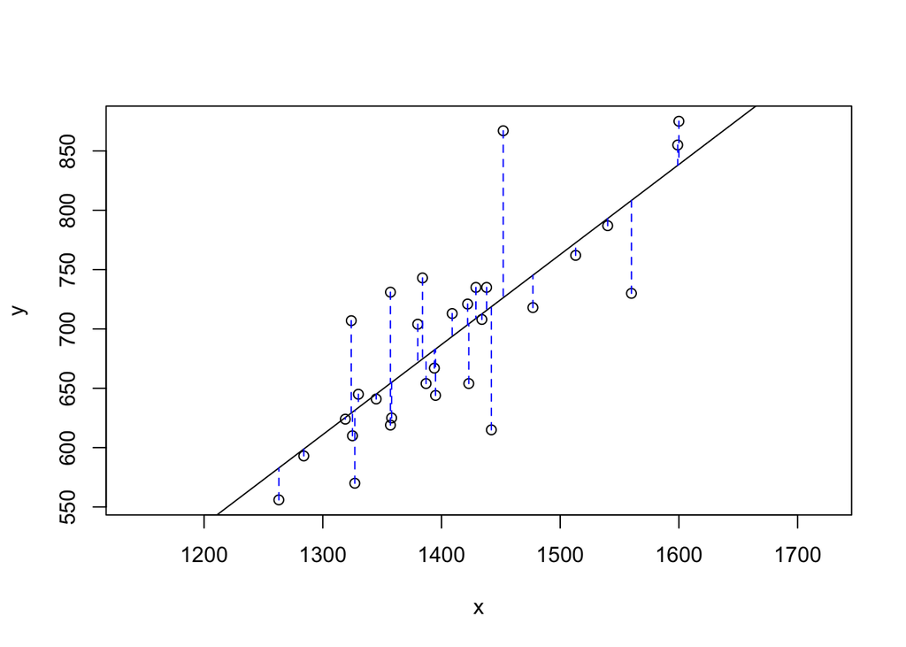

```
## Click two points to make a line.

## Call:
## lm(formula = y ~ x, data = pts)
##
## Coefficients:
## (Intercept)            x
##   -375.5600       0.7589
##
## Sum of Squares:  70638.75
```

```r
plot_ss(x = mlb11$hits, y = mlb11$runs)
```

The hits variable appears to predict runs better than at_bats since the r-squared value is higher and therefore the variability that can be explained by the model is higher.

runs ~ hits = 0.6419 runs ~ at_bats = 0.3729

```r
m2 <- lm(runs ~ hits, data = mlb11)
summary(m2)
```

```
##
## Call:
## lm(formula = runs ~ hits, data = mlb11)
##
## Residuals:
##      Min       1Q   Median       3Q      Max
## -103.718  -27.179   -5.233   19.322  140.693
##
## Coefficients:
##              Estimate Std. Error t value Pr(>|t|)
## (Intercept) -375.5600   151.1806  -2.484   0.0192 *
## hits           0.7589     0.1071   7.085 1.04e-07 ***
## ---
## Signif. codes:  0 '***' 0.001 '**' 0.01 '*' 0.05 '.' 0.1 ' ' 1
##
## Residual standard error: 50.23 on 28 degrees of freedom
## Multiple R-squared:  0.6419, Adjusted R-squared:  0.6292
## F-statistic:  50.2 on 1 and 28 DF,  p-value: 1.043e-07
```

Bat_avg has the highest R^2 value at 0.6561, therefore, best predicts runs.

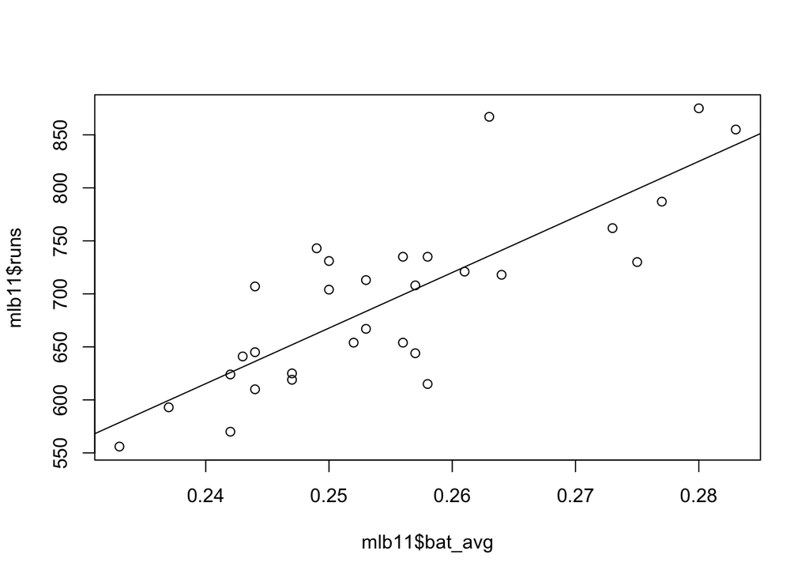

```r
plot(mlb11$runs ~ mlb11$bat_avg)
m3 <- lm(runs ~ bat_avg, data = mlb11)
abline(m3)
```

```r
summary(m3)
```

```
##
## Call:
## lm(formula = runs ~ bat_avg, data = mlb11)
##
## Residuals:
##     Min      1Q  Median      3Q     Max
## -94.676 -26.303  -5.496  28.482 131.113
##
## Coefficients:
##             Estimate Std. Error t value Pr(>|t|)
## (Intercept)   -642.8      183.1  -3.511  0.00153 **
## bat_avg       5242.2      717.3   7.308 5.88e-08 ***
## ---
## Signif. codes:  0 '***' 0.001 '**' 0.01 '*' 0.05 '.' 0.1 ' ' 1
##
## Residual standard error: 49.23 on 28 degrees of freedom
## Multiple R-squared:  0.6561, Adjusted R-squared:  0.6438
## F-statistic: 53.41 on 1 and 28 DF,  p-value: 5.877e-08
```

new_obs is the best predictor of runs with an R^2 value of 0.9349. The results does make sense because being on base and hitting a ball is a definitive criteria to make a run.

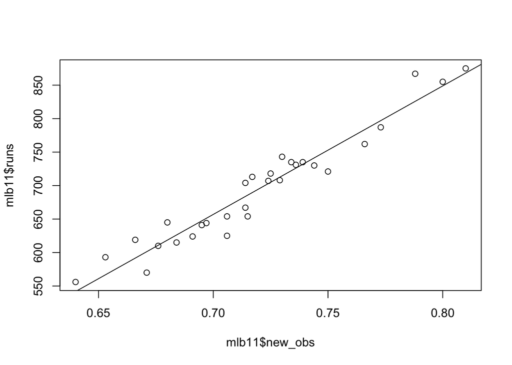

```r
plot(mlb11$runs ~ mlb11$new_obs)
m4 <- lm(runs ~ new_obs, data = mlb11)
abline(m4)
```

```r
summary(m4)
```

```
##
## Call:
## lm(formula = runs ~ new_obs, data = mlb11)
##
## Residuals:
##     Min      1Q  Median      3Q     Max
## -43.456 -13.690   1.165  13.935  41.156
##
## Coefficients:
##             Estimate Std. Error t value Pr(>|t|)
## (Intercept)  -686.61      68.93  -9.962 1.05e-10 ***
## new_obs      1919.36      95.70  20.057  < 2e-16 ***
## ---
## Signif. codes:  0 '***' 0.001 '**' 0.01 '*' 0.05 '.' 0.1 ' ' 1
##
## Residual standard error: 21.41 on 28 degrees of freedom
## Multiple R-squared:  0.9349, Adjusted R-squared:  0.9326
## F-statistic: 402.3 on 1 and 28 DF,  p-value: < 2.2e-16
```

- Check the model diagnostics for the regression model with the variable you decided was the best predictor for runs.

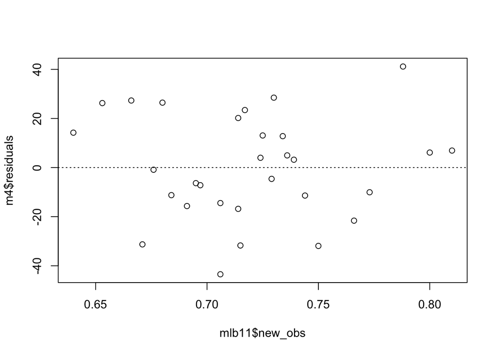

```r
plot(m4$residuals ~ mlb11$new_obs)
abline(h = 0, lty = 3)
```

There seems to be constant variability as the points do not seem to follow any patterns.

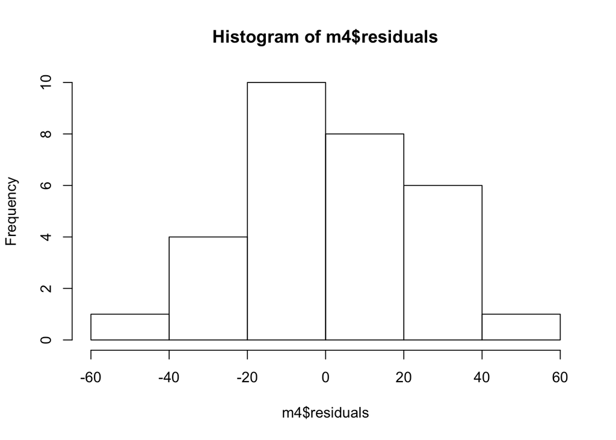

```r
hist(m4$residuals)
```

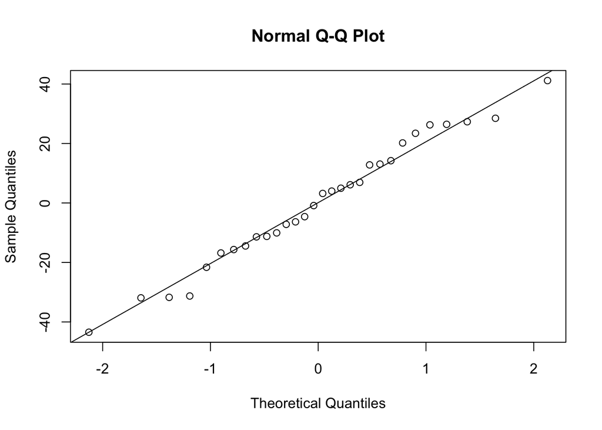

```r
qqnorm(m4$residuals)
qqline(m4$residuals)
```

The plot shows a very clear linear relationship.